# Name: Tanner Woods

## Question 2

### Question 2A

The mean value of IQ is $\mu_{IQ} \approx 101.28$

The sample standard variation of IQ is $\hat \sigma_{IQ} \approx 15.05$

The mean value of wage is $\mu_{Wage} \approx 957.95$

### Question 2B

The regression model predicts that $\Delta IQ = 15$ will result in $\Delta Wage \approx 124.55$. According to the summary statistics, the univariate model only explains — per the $R^2$ — approximately 9.6% of variation seen within wage.

### Question 2C

The regression model predicts that $\Delta IQ = 15$ will result in $\Delta Wage \approx 13.2$%.

### Question 2D

In the first model, the intercept can be interpreted as "at $IQ = 0$ you will see $Wage \approx 116.99$". In the second mode, the intercept can be interpreted as "at $IQ = 0$ you will see $Wage = e^{ln(Wage)} \approx 360.32$".

## Question 3

### Question 3A

While the residuals do seem to be mostly randomly distributed about the mean, there are a couple details that I would give some closer attention. First, the outlying halo of residuals surrounding the main body appears more dispersed along the positive upper frontier. Second, there is one major outlier present in the negative lower frontier at approximately 110 IQ points. Overall, the residuals still mostly appear randomly distributed.

### Question 3B

There does appear to be a handful of data points above the threshold of CD; this threshold can be defined as 4/N and is approximately 0.004, here. While the majority straddle the threshold, a small number sit well above it at a CD of 0.015 or greater.

### Question 3C

Similarly to 3B, a sizeable minority of data points break the threshold limits of approximately +/- 0.09. Furthermore, a small number of this minority far exceed the threshold limits.

### Question 3D

(See below)

### Question 3E

When adjusted by Cook's distance, there is a slight adjustment upward for the coefficient of IQ and a approximate 33% adjustment in the $R^2$ value. Conversely, there is a slight decrease seen within the intercept term's value and variance.

When adjusted by DFFITS, the same results seen in the adjustments from Cook's distance can be seen here. However, the results are even more marginal across the board.

### Question 3F

In initial outlier analysis, a major concern is runaway outlier removal. Each successive sweep for outliers adjusts the definition of an outlier within the dataset, which then results in previously "normal" observations being dubbed outliers and marked for removal. Fortunately, this can be easily solved by setting a threshold value prior to any removals and only performing the initial removal.

Another concern is the removal of a natural and legitimate observation under the guise of outlier removal, which can be seen in the case of an unlikely win by a political candidate. By removing such an observation, you could reduce the predictive strength of the regression and — for example — overestimate the effect of a candidate being mainstream on their chances of electoral success. Avoiding this situation requires a thorough understanding of the dataset being scanned for outliers.

# Code

```python
import numpy as np
import matplotlib.pyplot as plt
import scipy.stats as stats
import pandas as pd
import wooldridge as woo
import statsmodels.formula.api as smf
import seaborn as sns
```

## Question 2 (Code)

```python
wage = woo.data('wage2')
wage.describe()
```

|  | wage | hours | IQ | KWW | educ | exper | tenure | age | married | black | south | urban | sibs | brthord | meduc | feduc | lwage |
| --- | --- | --- | --- | --- | --- | --- | --- | --- | --- | --- | --- | --- | --- | --- | --- | --- | --- |
| count | 935.000000 | 935.000000 | 935.000000 | 935.000000 | 935.000000 | 935.000000 | 935.000000 | 935.000000 | 935.000000 | 935.000000 | 935.000000 | 935.000000 | 935.000000 | 852.000000 | 857.000000 | 741.000000 | 935.000000 |
| mean | 957.945455 | 43.929412 | 101.282353 | 35.744385 | 13.468449 | 11.563636 | 7.234225 | 33.080214 | 0.893048 | 0.128342 | 0.341176 | 0.717647 | 2.941176 | 2.276995 | 10.682614 | 10.217274 | 6.779004 |
| std | 404.360822 | 7.224256 | 15.052636 | 7.638788 | 2.196654 | 4.374586 | 5.075206 | 3.107803 | 0.309217 | 0.334650 | 0.474358 | 0.450385 | 2.306254 | 1.595613 | 2.849756 | 3.300700 | 0.421144 |
| min | 115.000000 | 20.000000 | 50.000000 | 12.000000 | 9.000000 | 1.000000 | 0.000000 | 28.000000 | 0.000000 | 0.000000 | 0.000000 | 0.000000 | 0.000000 | 1.000000 | 0.000000 | 0.000000 | 4.744932 |
| 25% | 669.000000 | 40.000000 | 92.000000 | 31.000000 | 12.000000 | 8.000000 | 3.000000 | 30.000000 | 1.000000 | 0.000000 | 0.000000 | 0.000000 | 1.000000 | 1.000000 | 8.000000 | 8.000000 | 6.505783 |
| 50% | 905.000000 | 40.000000 | 102.000000 | 37.000000 | 12.000000 | 11.000000 | 7.000000 | 33.000000 | 1.000000 | 0.000000 | 0.000000 | 1.000000 | 2.000000 | 2.000000 | 12.000000 | 10.000000 | 6.807935 |
| 75% | 1160.000000 | 48.000000 | 112.000000 | 41.000000 | 16.000000 | 15.000000 | 11.000000 | 36.000000 | 1.000000 | 0.000000 | 1.000000 | 1.000000 | 4.000000 | 3.000000 | 12.000000 | 12.000000 | 7.056175 |
| max | 3078.000000 | 80.000000 | 145.000000 | 56.000000 | 18.000000 | 23.000000 | 22.000000 | 38.000000 | 1.000000 | 1.000000 | 1.000000 | 1.000000 | 14.000000 | 10.000000 | 18.000000 | 18.000000 | 8.032035 |

```python
IQ_Samplestd = np.std(wage['IQ'], ddof = 1)
IQ_Samplestd
```

```
15.0526363702651
```

```python
wage_model = smf.ols('wage ~ IQ', data = wage).fit()
wage_model.summary()
```

OLS Regression Results

| Dep. Variable: | wage | R-squared: | 0.096 |
| --- | --- | --- | --- |
| Model: | OLS | Adj. R-squared: | 0.095 |
| Method: | Least Squares | F-statistic: | 98.55 |
| Date: | Thu, 20 Oct 2022 | Prob (F-statistic): | 3.79e-22 |
| Time: | 17:24:06 | Log-Likelihood: | -6891.4 |
| No. Observations: | 935 | AIC: | 1.379e+04 |
| Df Residuals: | 933 | BIC: | 1.380e+04 |
| Df Model: | 1 |  |  |
| Covariance Type: | nonrobust |  |  |

|  | coef | std err | t | P>\|t\| | [0.025 | 0.975] |
| --- | --- | --- | --- | --- | --- | --- |
| Intercept | 116.9916 | 85.642 | 1.366 | 0.172 | -51.081 | 285.064 |
| IQ | 8.3031 | 0.836 | 9.927 | 0.000 | 6.662 | 9.944 |

| Omnibus: | 208.281 | Durbin-Watson: | 1.802 |
| --- | --- | --- | --- |
| Prob(Omnibus): | 0.000 | Jarque-Bera (JB): | 532.184 |
| Skew: | 1.157 | Prob(JB): | 2.74e-116 |
| Kurtosis: | 5.882 | Cond. No. | 697. |

Notes:  
[1] Standard Errors assume that the covariance matrix of the errors is correctly specified.

```python
lwage_model = smf.ols('lwage ~ IQ', data = wage).fit()
lwage_model.summary()
```

OLS Regression Results

| Dep. Variable: | lwage | R-squared: | 0.099 |
| --- | --- | --- | --- |
| Model: | OLS | Adj. R-squared: | 0.098 |
| Method: | Least Squares | F-statistic: | 102.6 |
| Date: | Thu, 20 Oct 2022 | Prob (F-statistic): | 5.93e-23 |
| Time: | 17:24:06 | Log-Likelihood: | -468.85 |
| No. Observations: | 935 | AIC: | 941.7 |
| Df Residuals: | 933 | BIC: | 951.4 |
| Df Model: | 1 |  |  |
| Covariance Type: | nonrobust |  |  |

|  | coef | std err | t | P>\|t\| | [0.025 | 0.975] |
| --- | --- | --- | --- | --- | --- | --- |
| Intercept | 5.8870 | 0.089 | 66.131 | 0.000 | 5.712 | 6.062 |
| IQ | 0.0088 | 0.001 | 10.130 | 0.000 | 0.007 | 0.011 |

| Omnibus: | 32.293 | Durbin-Watson: | 1.793 |
| --- | --- | --- | --- |
| Prob(Omnibus): | 0.000 | Jarque-Bera (JB): | 45.621 |
| Skew: | -0.329 | Prob(JB): | 1.24e-10 |
| Kurtosis: | 3.859 | Cond. No. | 697. |

Notes:  
[1] Standard Errors assume that the covariance matrix of the errors is correctly specified.

## Question 3 (Code)

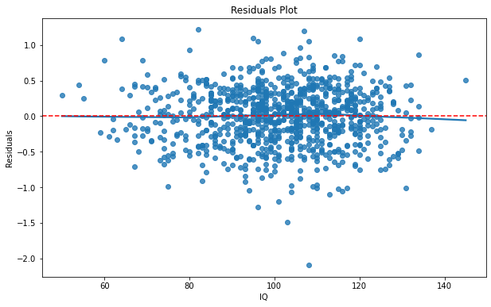

```python
plt.figure(figsize = (10, 6))
sns.regplot(x = wage['IQ'], y = lwage_model.resid, lowess = True)
plt.axhline(0, linestyle = '--', color = "red")
plt.ylabel("Residuals")
plt.title("Residuals Plot")
plt.show()
```

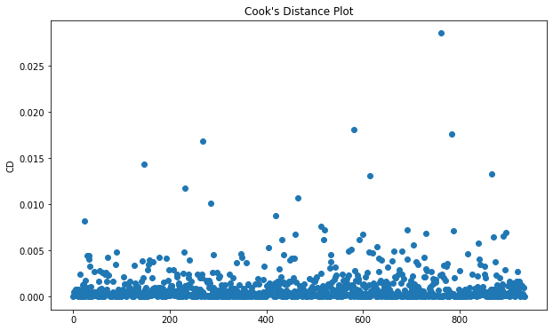

```python
cooks = lwage_model.get_influence().cooks_distance[0]
plt.figure(figsize = (10, 6))
plt.scatter(range(len(cooks)), cooks)
plt.ylabel("CD")
plt.title("Cook's Distance Plot")
plt.show()
```

```python
cooks
```

[output not shown]

[output cut: 179 more lines]

[output not shown]

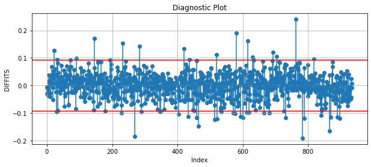

```python
dffits, threshold = lwage_model.get_influence().dffits
plt.figure(figsize = (10, 4))
plt.scatter(wage.index, dffits)
plt.axhline(threshold, color = 'red')
plt.axhline(-threshold, color = 'red')
plt.vlines(x = wage.index, ymin = 0, ymax = dffits)
plt.xlabel('Index')
plt.ylabel('DIFFITS')
plt.title("Diagnostic Plot")
plt.grid()
```

```python
WageNew_CD = wage[cooks<4/len(cooks)]
WageNew_Dffits = wage[dffits<threshold]
```

```python
lwage_model_CD = smf.ols('lwage ~ IQ', data = WageNew_CD).fit()
lwage_model_CD.summary()
```

OLS Regression Results

| Dep. Variable: | lwage | R-squared: | 0.131 |
| --- | --- | --- | --- |
| Model: | OLS | Adj. R-squared: | 0.130 |
| Method: | Least Squares | F-statistic: | 133.8 |
| Date: | Thu, 20 Oct 2022 | Prob (F-statistic): | 6.38e-29 |
| Time: | 17:56:15 | Log-Likelihood: | -335.20 |
| No. Observations: | 891 | AIC: | 674.4 |
| Df Residuals: | 889 | BIC: | 684.0 |
| Df Model: | 1 |  |  |
| Covariance Type: | nonrobust |  |  |

|  | coef | std err | t | P>\|t\| | [0.025 | 0.975] |
| --- | --- | --- | --- | --- | --- | --- |
| Intercept | 5.8304 | 0.084 | 69.463 | 0.000 | 5.666 | 5.995 |
| IQ | 0.0095 | 0.001 | 11.566 | 0.000 | 0.008 | 0.011 |

| Omnibus: | 7.323 | Durbin-Watson: | 1.876 |
| --- | --- | --- | --- |
| Prob(Omnibus): | 0.026 | Jarque-Bera (JB): | 6.736 |
| Skew: | -0.163 | Prob(JB): | 0.0345 |
| Kurtosis: | 2.727 | Cond. No. | 727. |

Notes:  
[1] Standard Errors assume that the covariance matrix of the errors is correctly specified.

```python
lwage_model_Dffits = smf.ols('lwage ~ IQ', data = WageNew_Dffits).fit()
lwage_model_Dffits.summary()
```

OLS Regression Results

| Dep. Variable: | lwage | R-squared: | 0.108 |
| --- | --- | --- | --- |
| Model: | OLS | Adj. R-squared: | 0.107 |
| Method: | Least Squares | F-statistic: | 111.6 |
| Date: | Thu, 20 Oct 2022 | Prob (F-statistic): | 1.10e-24 |
| Time: | 17:59:29 | Log-Likelihood: | -426.28 |
| No. Observations: | 919 | AIC: | 856.6 |
| Df Residuals: | 917 | BIC: | 866.2 |
| Df Model: | 1 |  |  |
| Covariance Type: | nonrobust |  |  |

|  | coef | std err | t | P>\|t\| | [0.025 | 0.975] |
| --- | --- | --- | --- | --- | --- | --- |
| Intercept | 5.8400 | 0.088 | 66.017 | 0.000 | 5.666 | 6.014 |
| IQ | 0.0091 | 0.001 | 10.562 | 0.000 | 0.007 | 0.011 |

| Omnibus: | 50.219 | Durbin-Watson: | 1.863 |
| --- | --- | --- | --- |
| Prob(Omnibus): | 0.000 | Jarque-Bera (JB): | 65.185 |
| Skew: | -0.501 | Prob(JB): | 7.00e-15 |
| Kurtosis: | 3.834 | Cond. No. | 713. |

Notes:  
[1] Standard Errors assume that the covariance matrix of the errors is correctly specified.